# Infix, Postfix and Prefix Expressions/Notations

Rumus matematika seringkali melibatkan ekspresi kompleks yang membutuhkan pemahaman yang jelas tentang urutan operasi. Untuk merepresentasikan ekspresi ini, kita menggunakan notasi yang berbeda, masing-masing dengan kelebihan dan kekurangannya sendiri. Dalam artikel ini, kita akan mengeksplorasi tiga notasi ekspresi umum: infix, prefiks, dan postfiks .

## Ekspresi Infix

Ekspresi infix adalah ekspresi matematika **di mana operator ditempatkan di antara operandnya**. Ini adalah notasi matematika paling umum yang digunakan oleh manusia. Misalnya, ekspresi "2 + 3" adalah ekspresi infix, di mana operator "+" ditempatkan di antara operand "2" dan "3".

**Notasi infix** mudah dibaca dan dipahami oleh manusia, tetapi dapat menjadi sulit bagi komputer untuk mengevaluasinya secara efisien. Hal ini karena urutan operasi harus diperhitungkan, dan tanda kurung dapat digunakan untuk mengganti urutan operasi standar.

### Cara Penulisan

- Notasi infix adalah notasi yang paling kita kenal. Misalnya, ekspresi "2 + 3" ditulis dalam notasi infix.

Dalam notasi infix, operator ditempatkan di antara operan yang dioperasikannya. Misalnya, dalam ekspresi "2 + 3", operator penjumlahan "+" ditempatkan di antara operan "2" dan "3"

Tanda kurung digunakan dalam notasi inxks untuk menentukan urutan operasi yang harus dilakukan. Misalnya, dalam ekspresi "(2 + 3) * 4", tanda kurung menunjukkan bahwa operasi penjumlahan harus dilakukan sebelum operasi perkaliahan.

### Aturan prioritas operator:

**Ekspresi infix** mengikuti aturan prioritas operator, yang menentukan urutan operator dievaluasi. Misalnya, perkalian dan pembagian memiliki prioritas lebih tinggi daripada penjumlahan dan pengurangan. Ini berarti bahwa dalam ekspresi "2 + 3 * 4", operasi perkalian akan dilakukan sebelum operasi penjumlahan.

Berikut tabel yang merangkum aturan prioritas operator untuk operator matematika umum:

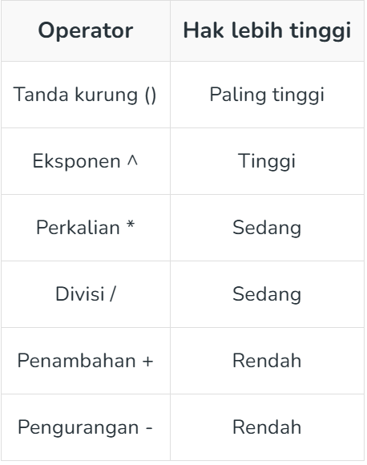

### Mengevaluasi Ekspresi Infix

Mengevaluasi ekspresi infix memerlukan pemrosesan tambahan untuk menangani urutan operasi dan tanda kurung. Pertama, ubah ekspresi infix ke notasi postfix . Ini dapat dilakukan menggunakan tumpukan atau algoritma rekursif. Kemudian, evaluasi ekspresi postfix tersebut.

Keunggulan Ekspresi Infix:

- Lebih alami dan lebih mudah dibaca serta dipahami oleh manusia.
- Digunakan secara luas dan didukung oleh sebagian besar bahasa pemrograman dan kalkulator.

Kekurangan Ekspresi Infix:

- Membutuhkan tanda kurung untuk menentukan urutan operasi.
- Bisa jadi sulit untuk diuraikan dan dievaluasi secara efisien.

## Ekspresi Prefix (Polish Notation)

Ekspresi prefix, juga dikenal sebagai notasi Polandia , adalah notasi matematika di mana operator mendahului operandnya. Ini berbeda dari notasi infiks yang lebih umum , di mana operator ditempatkan di antara operandnya .

Dalam notasi prefix, operator ditulis terlebih dahulu, diikuti oleh operandnya. Misalnya, ekspresi infix "a + b" akan ditulis sebagai "+ a b" dalam notasi prefix.

### Mengevaluasi Ekspresi Prefix

Mengevaluasi ekspresi prefix dapat berguna dalam skenario tertentu, seperti saat menangani ekspresi yang memiliki sejumlah besar tanda kurung bersarang atau saat menggunakan bahasa pemrograman berbasis tumpukan.

Keunggulan Ekspresi Prefix:

- Tidak perlu tanda kurung, karena operator selalu mendahului operandnya.
- Lebih mudah diuraikan dan dievaluasi menggunakan algoritma berbasis tumpukan.
- Bisa lebih efisien dalam situasi tertentu, seperti saat menangani ekspresi yang memiliki banyak tanda kurung bersarang.

Kekurangan Ekspresi Prefix

- Bisa jadi sulit dibaca dan dipahami oleh manusia.
- Tidak sesering digunakan seperti notasi infix.

## Ekspresi Postfix (Notasi Polandia Terbalik)

Ekspresi postfix, juga dikenal sebagai Notasi Polandia Terbalik (RPN) , adalah notasi matematika di mana operator mengikuti operandnya . Ini berbeda dari notasi infix yang lebih umum, di mana operator ditempatkan di antara operandnya.

Dalam notasi postfix, operan ditulis terlebih dahulu, diikuti oleh operator. Misalnya, ekspresi infix "5 + 2" akan ditulis sebagai "5 2 +" dalam notasi postfix.

### Mengevaluasi Ekspresi Postfix (Notasi Polandia Terbalik)

Mengevaluasi ekspresi postfix dapat berguna dalam skenario tertentu, seperti saat menangani ekspresi yang memiliki banyak tanda kurung bersarang atau saat menggunakan bahasa pemrograman berbasis tumpukan (stack).

Kekurangan Ekspresi Postfix:

- Membutuhkan algoritma berbasis tumpukan untuk evaluasi.
- Dalam situasi tertentu, metode ini bisa kurang efisien dibandingkan notasi prefiks.

## Perbandingan Ekspresi Infiks, Prefiks, dan Postfiks

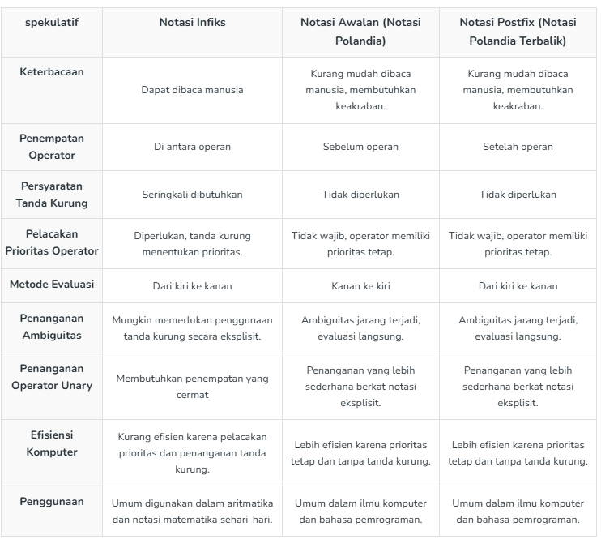

## Infix to Postfix Expression:

Diberikan sebuah string s yang mewakili ekspresi infix ("operand1 operator operand2"), Ubahlah ke notasi postfixnya ("operand1 operand2 operator").

Catatan: Urutan prioritasnya adalah sebagai berikut: (^) memiliki prioritas tertinggi dan dievaluasi dari kanan ke kiri, (* dan /) berada di urutan berikutnya dengan asosiatif dari kiri ke kanan, dan (+ dan -) memiliki prioritas terendah dengan asosiatif dari kiri ke kanan.

Contoh:

```
Input: s = "a*(b+c)/d"
Output: abc+*d/
Penjelasan: Ekspresi tersebut adalah a * (b + c) / d. Pertama, di dalam tanda kurung, b + c menjadi bc+. Sekarang ekspresi tersebut terlihat seperti a * (bc+) / d. Selanjutnya, kalikan a dengan (bc+), sehingga menjadi abc+* . Terakhir, bagi hasil ini dengan d, sehingga menjadi abc+*d/.

Input: s = "a+b*c+d"
Output: abc*+d+
Penjelasan: Ekspresi a + b * c + d dikonversi dengan terlebih dahulu melakukan b * c → bc*, kemudian menambahkan a → abc*+, dan akhirnya menambahkan d → abc*+d+.
```

#### [Pendekatan] Menggunakan Stack - Waktu O(n) dan Ruang O(n)

`Ide dasarnya adalah memindai ekspresi dari kiri ke kanan, langsung menempatkan operan (a, b, c…) dalam urutan yang sama seperti yang muncul ke dalam hasil dan menempatkan operator (+, -, *, /, ^) setelah operannya. Operator ditangani menggunakan tumpukan (stack) sehingga prioritas dan asosiatifitas tetap terjaga.`

### Bagaimana Mempertahankan Prioritas dan Asosiativitas?

Untuk mempertahankan prioritas dan asosiatifitas operator, bandingkan setiap operator baru dengan operator teratas di tumpukan. Keluarkan operator dari tumpukan jika operator tersebut memiliki prioritas lebih tinggi, atau jika operator tersebut memiliki prioritas yang sama dan operator baru tersebut bersifat asosiatif kiri (+, -, *, /). Jika operator baru tersebut bersifat asosiatif kanan (^), biarkan operator di tumpukan tetap di tempatnya. Masukkan operator baru ke dalam tumpukan. Tanda kurung ditangani secara khusus: '(' dimasukkan ke dalam tumpukan, dan ketika ')' ditemui, operator dikeluarkan hingga ditemukan '(' yang sesuai.

Ilustrasi:

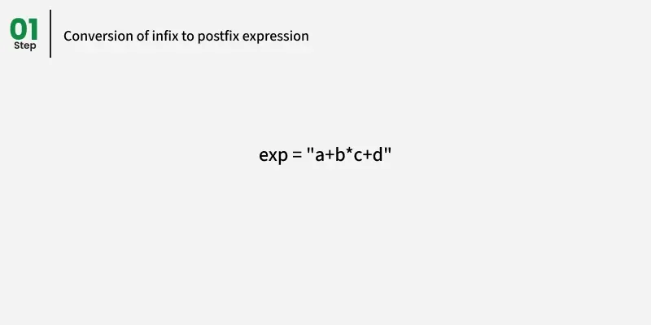

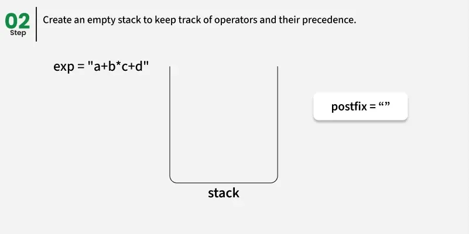

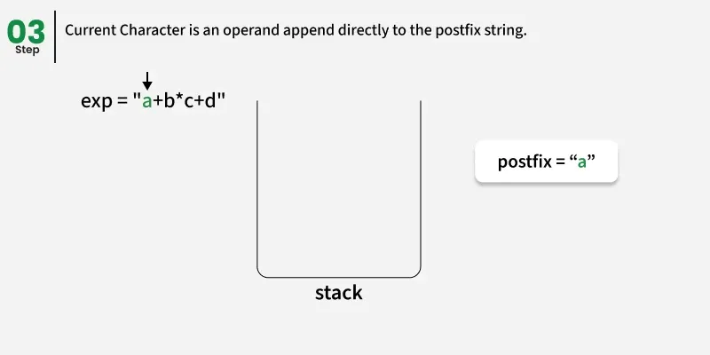

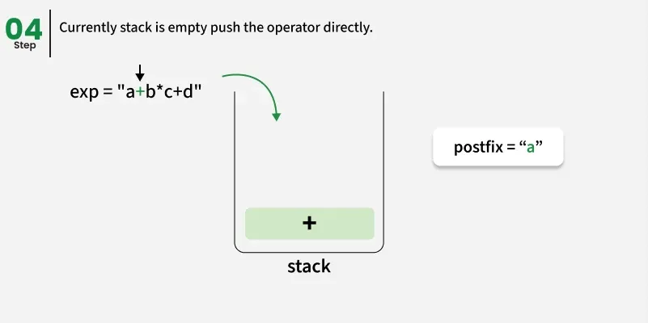

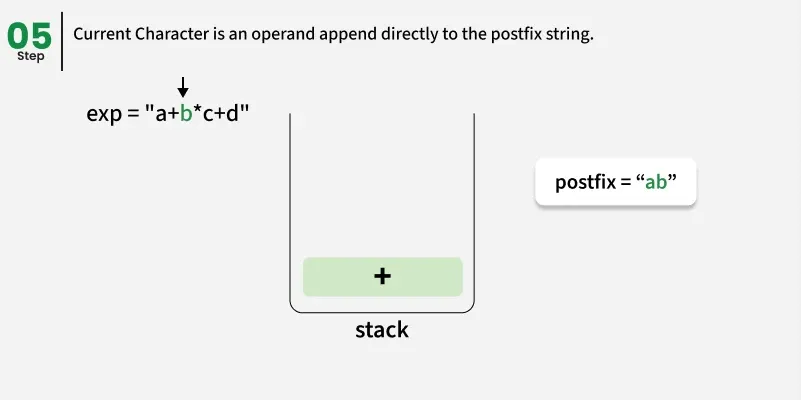

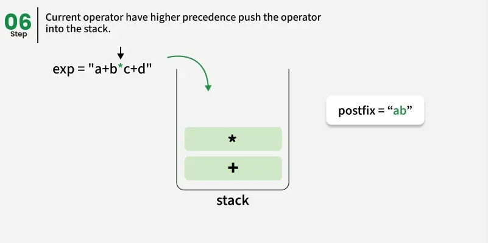

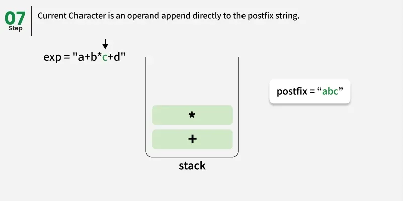

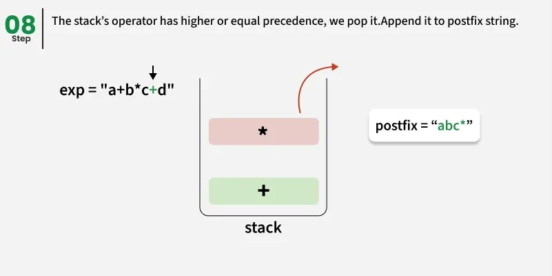

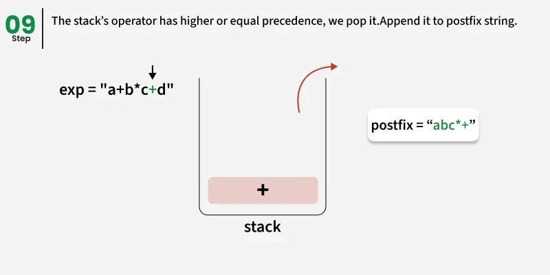

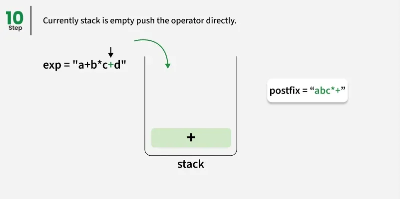

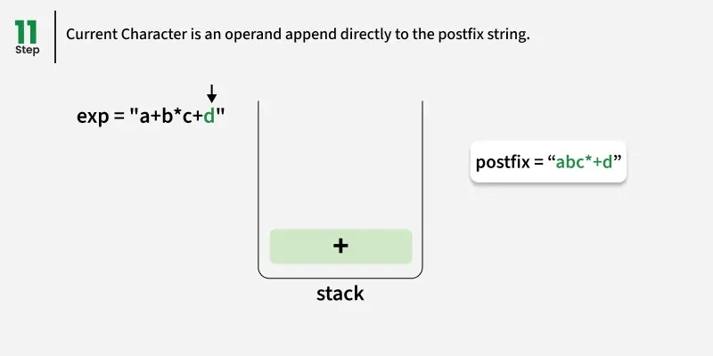

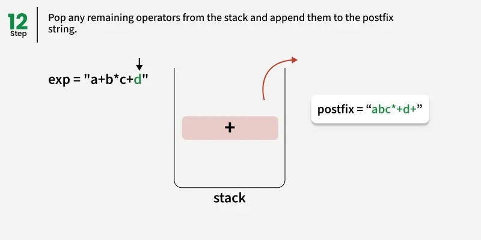

```python
def prec(c):
    if c == '^':
        return 3
    elif c == '/' or c == '*':
        return 2
    elif c == '+' or c == '-':
        return 1
    else:
        return -1

def isRightAssociative(c):
    return c == '^'

def infixToPostfix(s):
    st = []
    res = []

    for c in s:
        # If operand, add to result
        if ('a' <= c <= 'z') or ('A' <= c <= 'Z') or ('0' <= c <= '9'):
            res.append(c)

        # If '(', push to stack
        elif c == '(':
            st.append('(')

        # If ')', pop until '('
        elif c == ')':
            while st and st[-1] != '(':
                res.append(st.pop())
            st.pop()

        # If operator
        else:
            while st and st[-1] != '(' and \
                (prec(st[-1]) > prec(c) or (prec(st[-1]) == prec(c) \
                                    and not isRightAssociative(c))):
                res.append(st.pop())
            st.append(c)

    # Pop remaining operators
    while st:
        res.append(st.pop())

    return ''.join(res)

if __name__ == '__main__':
    exp = "a*(b+c)/d"
    print(infixToPostfix(exp))
```

```
abc+*d/
```

## Infix To Prefix Notation

Diberikan sebuah string s yang mewakili ekspresi infiks ("operand1 operator operand2"), Ubahlah string tersebut menjadi notasi prefiksnya ("operator operand1 operand2").

Catatan: Urutan prioritasnya adalah sebagai berikut: (^) memiliki prioritas tertinggi dan dievaluasi dari kanan ke kiri, (* dan /) berada di urutan berikutnya dengan asosiatif dari kiri ke kanan, dan (+ dan -) memiliki prioritas terendah dengan asosiatif dari kiri ke kanan.

Contoh:

```
Input: s = " a*(b+c)/d "
Output: /*a+bcd
Penjelasan: Ekspresi infiksnya adalah a*(b+c)/d. Pertama, di dalam tanda kurung, b + c menjadi +bc. Sekarang ekspresinya terlihat seperti a*(+bc)/d. Selanjutnya, kalikan a dengan (+bc), sehingga menjadi *a+bc. Terakhir, bagi hasil ini dengan d, sehingga menjadi /*a+bcd.
```

#### [Pendekatan 1] Menggunakan Stack - Waktu O(n) dan Ruang O(n)

`Ide dasarnya adalah memindai ekspresi dari kanan ke kiri, langsung menempatkan operan (a, b, c…) ke dalam hasil sesuai dengan kemunculannya. Operator (+, -, *, /, ^) ditangani menggunakan tumpukan (stack) sehingga prioritas dan asosiatifitas tetap terjaga.`

### Bagaimana Mempertahankan Prioritas dan Asosiativitas?

Untuk menjaga prioritas dan asosiatifitas, ketika operator baru muncul, bandingkan dengan operator yang berada di atas tumpukan. Keluarkan operator dari tumpukan jika memiliki prioritas lebih tinggi, atau jika memiliki prioritas yang sama dan operator baru tersebut asosiatif kanan (^). Operator asosiatif kiri (+, -, *, /) tidak menyebabkan pengeluaran. Masukkan operator baru ke dalam tumpukan. Untuk tanda kurung (saat memindai dari kanan ke kiri), masukkan ')' ke dalam tumpukan, dan ketika '(' ditemukan, keluarkan operator hingga ')' ditemukan.

Terakhir, keluarkan semua operator yang tersisa dari tumpukan dan tambahkan ke hasilnya. Kemudian, balikkan hasilnya untuk mendapatkan ekspresi awalan yang benar.

```python
# function to return precedence of operators
def precedence(c):
    if c == '^':
        return 3
    elif c in ('*', '/'):
        return 2
    elif c in ('+', '-'):
        return 1
    else:
        return -1

# function to check if operator is right-associative
def isRightAssociative(c):
    return c == '^'

# function to check if a character is an operator
def isOperator(c):
    return c in "+-*/^"

# function to convert infix expression to prefix
def infixToPrefix(s):
    st = []
    result = []

    # scan from right to left
    for c in reversed(s):
        if c.isalnum():
            result.append(c)
        elif c == ')':
            st.append(c)
        elif c == '(':
            while st and st[-1] != ')':
                result.append(st.pop())
            if st:
                st.pop()  # remove ')'
        elif isOperator(c):
            while (st and isOperator(st[-1]) and
                  (precedence(st[-1]) > precedence(c) or
                  (precedence(st[-1]) == precedence(c) and isRightAssociative(c)))):
                result.append(st.pop())
            st.append(c)

    # pop remaining operators
    while st:
        result.append(st.pop())

    # reverse at the end to get correct prefix
    return ''.join(reversed(result))

if __name__ == "__main__":
    s = "a*(b+c)/d"
    print(infixToPrefix(s))
```

```
/*a+bcd
```

### [Pendekatan 2] Menggunakan Metode Postfix dan Reverse - Waktu O(n) dan Ruang O(n)

Untuk mengubah ekspresi infiks menjadi prefiks, kita menggunakan metode infiks-ke-postfiks dengan sedikit modifikasi.

- Pertama, kita membalikkan ekspresi infiks karena prefiks dievaluasi dari kanan ke kiri (kebalikan dari postfiks).
- Saat membalikkan, kita menukar '(' dengan ')' untuk mempertahankan pengelompokan subekspresi yang benar.
- Sekarang, kita mengubah ekspresi yang telah dimodifikasi ini menjadi postfix menggunakan metode berbasis tumpukan standar.
- Terakhir, kita membalikkan ekspresi postfix yang dihasilkan. Ini memberikan bentuk prefix yang benar.

> Catatan: Awalan = kebalikan( akhiran( kebalikan(infiks) ) )

Ilustrasi:

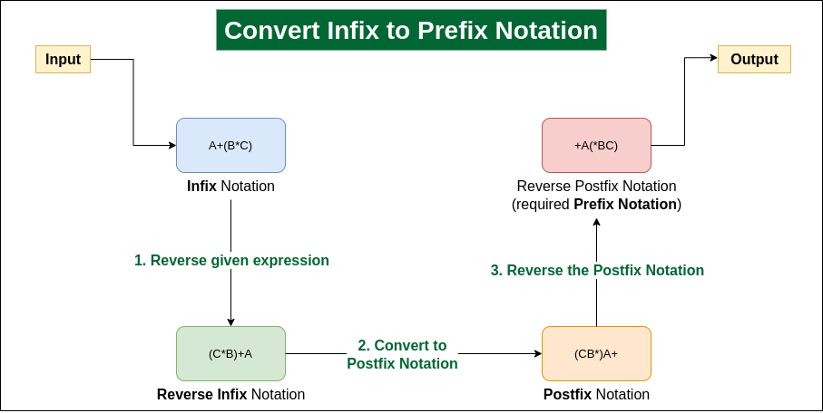

```python
# function to return precedence
def precedence(c):
    if c == '^': return 3
    elif c in ['*', '/']: return 2
    elif c in ['+', '-']: return 1
    else: return -1

def isOperator(c):
    return c in ['+', '-', '*', '/', '^']

# check if operator is right-associative
def isRightAssociative(c):
    return c == '^'

# function to convert infix to prefix
# using reverse-trick
def infixToPrefix(s):
    # reverse string
    s = s[::-1]

    # swap ( and )
    s = ''.join(')' if c == '(' else '(' if c == ')' else c for c in s)

    st = []
    result = []

    # infix to postfix on reversed string
    for c in s:
        if c.isalnum():
            result.append(c)
        elif c == '(':
            st.append(c)
        elif c == ')':
            while st and st[-1] != '(':
                result.append(st.pop())
            if st: st.pop()
        elif isOperator(c):
            while (st and st[-1] != '(' and
                   (precedence(st[-1]) > precedence(c) or
                   (precedence(st[-1]) == precedence(c) and isRightAssociative(c)))):
                result.append(st.pop())
            st.append(c)

    while st:
        result.append(st.pop())

    # reverse result
    return ''.join(result[::-1])

if __name__ == "__main__":
    s = "a*(b+c)/d"
    print(infixToPrefix(s))
```

```
/*a+bcd
```

## Prefix to Infix Conversion

Infiks : Suatu ekspresi disebut ekspresi infiks jika operator muncul di antara operan dalam ekspresi tersebut. Bentuknya sederhana, yaitu (operan1 operator operan2). Contoh: (A+B) * (CD)

prefiks (Prefix ): Suatu ekspresi disebut ekspresi awalan jika operator muncul dalam ekspresi sebelum operan. Bentuknya sederhana, yaitu (operator operan1 operan2). Contoh: *+AB-CD (Infiks: (A+B)* (CD))

Diberikan sebuah ekspresi Prefiks, ubahlah menjadi ekspresi Infiks. Komputer biasanya melakukan perhitungan baik dalam bentuk prefiks maupun postfix (biasanya postfix). Namun bagi manusia, ekspresi Infiks lebih mudah dipahami daripada ekspresi prefiks. Oleh karena itu, konversi diperlukan agar manusia dapat memahaminya.

```
Contoh:
Input:   Prefix: *+AB-CD
Output: Infix: ((A+B)*(CD))

Input:   Prefix: *-A/BC-/AKL
Output: Infix: ((A-(B/C))*((A/K)-L))
```

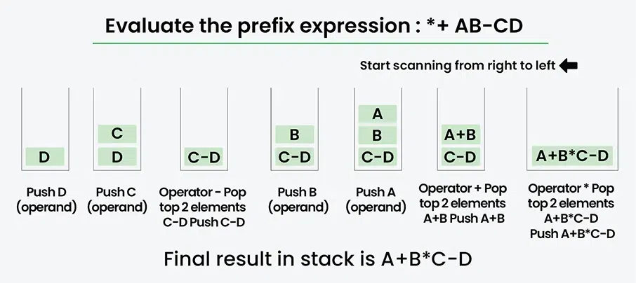

### Algoritma untuk Konversi prefix ke infix :

- Bacalah ekspresi prefix secara terbalik (dari kanan ke kiri)
- Jika simbol tersebut merupakan operan, maka masukkan ke dalam Stack.
- Jika simbol tersebut adalah operator, maka keluarkan dua operand dari Stack.
- Buat string dengan menggabungkan kedua operand dan operator di antaranya.
- string = (operand1 + operator + operand2) Dan masukkan kembali string hasil tersebut ke Stack.
- Ulangi langkah-langkah di atas hingga akhir ekspresi prefix.
- Pada akhirnya, tumpukan hanya akan berisi 1 string, yaitu string hasil.

Pelaksanaan:

```python
# Python Program to convert prefix to Infix
def prefixToInfix(prefix):
    stack = []

    # read prefix in reverse order
    i = len(prefix) - 1
    while i >= 0:
        if not isOperator(prefix[i]):

            # symbol is operand
            stack.append(prefix[i])
            i -= 1
        else:

            # symbol is operator
            str = "(" + stack.pop() + prefix[i] + stack.pop() + ")"
            stack.append(str)
            i -= 1

    return stack.pop()

def isOperator(c):
    if c == "*" or c == "+" or c == "-" or c == "/" or c == "^" or c == "(" or c == ")":
        return True
    else:
        return False

# Driver code
if __name__=="__main__":
    str = "*-A/BC-/AKL"
    print(prefixToInfix(str))

# This code is contributed by avishekarora
```

```
((A-(B/C))*((A/K)-L))
```

## Postfix to Prefix Conversion

Ekspresi postfix : Suatu ekspresi disebut ekspresi postfix jika operator muncul dalam ekspresi setelah operan. Bentuknya sederhana, yaitu (operan1 operan2 operator). Contoh: AB+CD-* (Infix: (A+B) * (CD)) Preflan (Prefix ): Suatu ekspresi disebut ekspresi awalan jika operator muncul dalam ekspresi sebelum operan. Bentuknya sederhana, yaitu (operator operan1 operan2). Contoh: *+AB-CD (Infiks: (A+B)* (CD))

Pernyataan Masalah Diberikan sebuah ekspresi Postfix , ubahlah menjadi ekspresi Prefix .

```
Contoh:

Input:   Postfix: AB+CD-*
Output: Prefix: *+AB-CD
Penjelasan: Postfix ke Infix: (A+B) * (CD)
              Infix ke Prefix: *+AB-CD

Input:   Postfix: ABC/-AK/L-*
Output: Prefix: *-A/BC-/AKL
Penjelasan: Postfix ke Infix: ((A-(B/C))*((A/K)-L))
              Infix ke Prefix: *-A/BC-/AKL
```

#### Algoritma untuk Konversi Postfix ke Prefix :

Kita menggunakan tumpukan (stack) untuk membangun ekspresi awalan (prefix expression) langkah demi langkah:

- Bacalah ekspresi Postfix dari kiri ke kanan.
- Jika simbol tersebut merupakan operan, maka masukkan ke dalam Stack.
- Jika simbol tersebut adalah operator, maka keluarkan dua operand dari Stack.
- Buat string dengan menggabungkan kedua operand dan operator sebelum keduanya.
- string = operator + operand2 + operand1 Dan masukkan kembali string hasil tersebut ke Stack.
- Ulangi langkah-langkah di atas hingga akhir ekspresi Postfix.

Berikut adalah implementasi dari ide di atas:

```python
# Python3 Program to convert postfix to prefix

# function to check if
# character is operator or not
def isOperator(x):

    if x == "+":
        return True

    if x == "-":
        return True

    if x == "/":
        return True

    if x == "*":
        return True

    return False

# Convert postfix to Prefix expression


def postToPre(post_exp):

    s = []

    # length of expression
    length = len(post_exp)

    # reading from right to left
    for i in range(length):

        # check if symbol is operator
        if (isOperator(post_exp[i])):

            # pop two operands from stack
            op1 = s[-1]
            s.pop()
            op2 = s[-1]
            s.pop()

            # concat the operands and operator
            temp = post_exp[i] + op2 + op1

            # Push string temp back to stack
            s.append(temp)

        # if symbol is an operand
        else:

            # push the operand to the stack
            s.append(post_exp[i])


    ans = ""
    for i in s:
        ans += i
    return ans


# Driver Code
if __name__ == "__main__":

    post_exp = "AB+CD-"

    # Function call
    print("Prefix : ", postToPre(post_exp))

# This code is contributed by AnkitRai01
```

```
Prefix :  +AB-CD
```

`Kompleksitas Waktu: O(N) (Kita menelusuri ekspresi sekali, setiap operasi membutuhkan waktu konstan.)`

## Prefix to Postfix Conversion

Diberikan sebuah ekspresi Prefix, ubahlah menjadi ekspresi Postfix. Konversi ekspresi Prefix langsung ke Postfix tanpa melalui proses konversi terlebih dahulu ke Infix dan kemudian ke Postfix jauh lebih baik dalam hal komputasi dan pemahaman ekspresi yang lebih baik (Komputer mengevaluasi menggunakan ekspresi Postfix).

Mari kita bahas tentang notasi awalan (prefix) dan notasi akhiran (postfix):

Prefix: Suatu ekspresi disebut ekspresi awalan jika operator muncul dalam ekspresi sebelum operan. Bentuknya sederhana, yaitu (operator operan1 operan2). Contoh: *+AB-CD (Infiks: (A+B)* (CD))

Ekspresi postfix : Suatu ekspresi disebut ekspresi postfix jika operator muncul dalam ekspresi setelah operan. Bentuknya sederhana, yaitu (operan1 operan2 operator). Contoh: AB+CD-* (Infix: (A+B * (CD))

Contoh: Masukan: Awalan: *+AB-CD Keluaran: Akhiran: AB+CD-* Penjelasan: Awalan ke Sisipan: (A+B) * (CD) Sisipan ke Akhiran: AB+CD-* Masukan: Awalan: *-A/BC-/AKL Keluaran: Akhiran: ABC/-AK/L-* Penjelasan: Awalan ke Sisipan: (A-(B/C))*((A/K)-L) Sisipan ke Akhiran: ABC/-AK/L-*

#### Algoritma untuk Prefix ke Postfix :

- Bacalah ekspresi Prefix secara terbalik (dari kanan ke kiri)
- Jika simbol tersebut merupakan operan, maka masukkan ke dalam Stack.
- Jika simbol tersebut adalah operator, maka keluarkan dua operand dari Stack.
- Buat string dengan menggabungkan kedua operand dan operator setelahnya.
- string = operand1 + operand2 + operator Kemudian masukkan kembali string hasil tersebut ke Stack.
- Ulangi langkah-langkah di atas hingga akhir ekspresi Awalan

Kode untuk konversi prefix ke postfix:

```python
# Write Python3 code here
# -*- coding: utf-8 -*-

# Example Input
s = "*-A/BC-/AKL"

# Stack for storing operands
stack = []

operators = set(['+', '-', '*', '/', '^'])

# Reversing the order
s = s[::-1]

# iterating through individual tokens
for i in s:

    # if token is operator
    if i in operators:

        # pop 2 elements from stack
        a = stack.pop()
        b = stack.pop()

        # concatenate them as operand1 +
        # operand2 + operator
        temp = a+b+i
        stack.append(temp)

    # else if operand
    else:
        stack.append(i)

# printing final output
print(*stack)
```

```
ABC/-AK/L-*
```

`Kompleksitas Waktu: O(N), karena kita menggunakan loop untuk menelusuri ekspresi.`

`Ruang Tambahan: O(N), karena kita menggunakan stack untuk ruang tambahan.`

## Postfix to Infix

Konversi notasi postfix ke infix melibatkan transformasi ekspresi di mana operator mengikuti operandnya (notasi postfix) menjadi ekspresi matematika standar dengan operator ditempatkan di antara operand (notasi infix). Konversi ini meningkatkan keterbacaan dan pemahaman.

- Ekspresi infiks : Ekspresi berbentuk a op b. Ketika sebuah operator berada di antara setiap pasangan operan.
- Ekspresi postfix : Ekspresi yang berbentuk ab op. Ketika sebuah operator diikuti untuk setiap pasangan operan.

Pendekatan: Menggunakan Stack - Waktu O(n) dan Ruang O(n)

- Inisialisasi Stack – Buat stack kosong.
- Memproses Simbol Masukan – Membaca simbol satu per satu dari masukan.
- Tangani Operan – Dorong operan ke dalam tumpukan.
- Operator Handle – Keluarkan dua nilai teratas, bentuk ekspresi infiks, dan masukkan kembali.
- Ambil Ekspresi Akhir – Nilai yang tersisa dalam tumpukan adalah ekspresi infiks yang diinginkan.

```python
def isOperand(x):
    return ((x >= 'a' and x <= 'z') or
            (x >= 'A' and x <= 'Z'))

# Get Infix for a given postfix
# expression
def getInfix(exp) :

    s = []

    for i in exp:

        # Push operands
        if (isOperand(i)) :
            s.insert(0, i)

        # We assume that input is a
        # valid postfix and expect
        # an operator.
        else:

            op1 = s[0]
            s.pop(0)
            op2 = s[0]
            s.pop(0)
            s.insert(0, "(" + op2 + i +
                             op1 + ")")

    # There must be a single element in
    # stack now which is the required
    # infix.
    return s[0]

# Driver Code
if __name__ == '__main__':

    exp = "ab*c+"
    print(getInfix(exp.strip()))

# This code is contributed by
# Shubham Singh(SHUBHAMSINGH10)
```

```
((a*b)+c)
```